# OpenCL application walkthrough - Matrix Multiplication

Often it is helpful to see a complete example that is fully explained in every detail. Matrix multiplication is a commonly employed compute operation and there are many math problems in STEM that can be reduced to a matrix multiplication. We use it for a complete example with OpenCL. The multiplication of matrices **A** and **B** proceeds by taking the **dot product** between every row **i0** in matrix **A** and every column **i1** of matrix **B**. If we multiply (elementwise) a row (at index **i0**) of matrix **A** with a column (at index **i1**) of Matrix B, then the dot product is the sum of the multiplied elements. The result of each dot product is then inserted into matrix **C** at position (i0,i1).

[figure not shown]

Multiplying matrices A and B to get C.

The strategy we use here is to associate a kernel instance with every point (i0,i1) in Matrix C. This means the grid for this problem must be large enough to cover the entire size of Matrix C. Every kernel will compute its own dot product and place the result in Matrix C. The source code for the example is in mat_mult.cpp. Click on the link and open up the file in a different window.

## The example program

Let's run the application and see the results, then we can understand how it works.

### Compile and run the appliciation

On your terminal change directory to **L3_Matrix_Multiplication** and compile and run with these commands (without the exclamation mark !).

```python
!make clean; make; ./mat_mult.exe
```

```
rm -r *.exe
CC -g -fopenmp -O2 -I../include mat_mult.cpp -o mat_mult.exe -lOpenCL
	               name: gfx1035
	     Device version: OpenCL 2.0
	 global memory size: 536 MB
	    max buffer size: 456 MB
	     max local size: (1024,1024,1024)
	     max work-items: 256
Maximum error (infinity norm) is: 1.52588e-05
```

You should now be able to see the output files.

```python
!ls *.dat
```

```
array_A.dat  array_B.dat  array_C.dat
```

### Read in the answer and verify results

A raw dump of the matrices in binary format is **not self-describing** nor is it **architecture independent**, however for teaching and debugging purposes it does provide a way to quickly examine the output of the code. We use the following code to read in the matrices, plot the output from the program, and compare it with a known solution from Numpy.

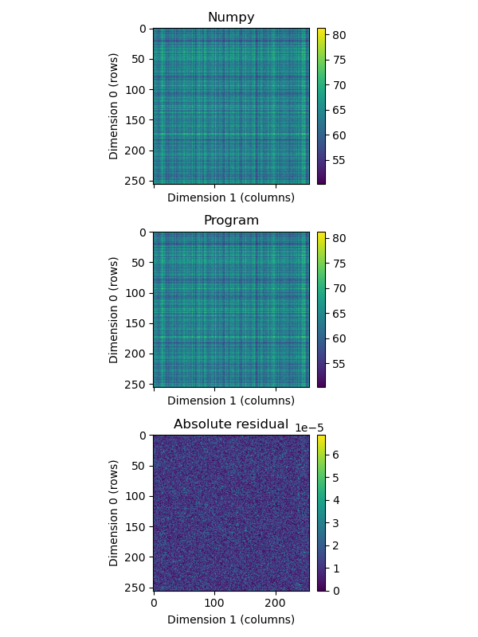

```python
import os
import sys
import numpy as np
sys.path.insert(0, os.path.abspath("../include"))

import py_helper

%matplotlib widget

# Data type to use for matrices
dtype=np.float32

defines=py_helper.load_defines("mat_size.hpp")

# Load the size of the matrix from file
NCOLS_A = defines["NCOLS_A"]
NROWS_C = defines["NROWS_C"]
NCOLS_C = defines["NCOLS_C"]

# A is of size (NROWS_C, NCOLS_A)
# B is of size (NCOLS_A, NCOLS_C)
# C is of size (NROWS_C, NCOLS_C)

mat_mul=py_helper.MatMul(NCOLS_A, NROWS_C, NCOLS_C, dtype)
mat_mul.load_data()
mat_mul.check_data()
```

The absolute residual is on the order of $10^-5$, which is approximatelyy the spacing from one floating point representation to the next for values around 70. Therefore we are confident the answer is within acceptable limits.